# Ch. 4 Generating Random Processes (Ch. 4)

18 Feb 2021 (*updated: 2021-02-18)*

## i. Admin & Startup

## schedule review / Problem Set 3 due Friday

- Let’s review the schedule and place today’s learning in context.
- Please complete Ch. 3 Problem Set, due Friday.
- The midterm exam will be released this week, due next Friday 26 Feb 2021.
- Questions regarding Ch. 3 HW?

## Today’s plan

I. Definitions, motivation, and intuition for stochastic processes  
II. Finish Ch. 4 Generating Random Processes Rizzo content/examples  
III. Ch. 4 Problem prompt discussion / hints

*Please contribute questions and comments*

## I. Stochastic processes

- More on random processes
- adapted from Stirzaker, David. “Stochastic processes and models.” OUP Catalogue (2005).

## Stochastic processes

### A *stochastic process* is a collection of rvs. \(( X(t): t \in T)\) where \(t\) is the parameter that runs over an index set \(T\).

## Characterized by 3 principal properties

1. the state space
2. the parameter set
3. the dependence relations (the joint distribution) of the various random variables \(X(t)\).

## Examples

- \(X(t)\) is the number of emails in your inbox at time \(t\) (continuous time).
- Your bank balance on day \(t\) (discrete time).
- The number of active covid cases at UNR for week \(w\) (16 students and 6 faculty as of 18 Feb 2021).
- Please think of an example.

## How to study

- Described mathematically in a way that reflects the practical / experimental setting
- These assumptions/formalizations are provided in a **local** manner.
- For example, the *state* \(X(t)\) at time \(t\), the interarrival times are iid exponential, etc.
- From these short-term description the analyst often seeks to underestand the **global** long-run behavior.

## II. Ch. 4 Stochastic Processes continued

## 4.1.1 Poisson Processes

- typo in Equation 4.1 should be \(P( N(s + t) - N(s) = n ) = \frac{ e^{- (\lambda t)}(\lambda t)^n} {n!}, 0 < s < s + t, n \geq 0\).
- We see that the interarrival times are exponential on p.99-100.
- Define independent rvs \(\{X_r : r \geq 1\} \sim Exponential(\lambda)\)
- and their convolution \(T_n = \sum_{r \geq 1} X_r, T_0 = 0\).
- Define \(N(t) = max \{n: T_n \leq t \}\). This is a counting process and a Poisson process.
- OR alternatively define \(N(t) = min \{n: T_n > t \} - 1\) as in Rizzo.

## Slightly modified Example 4.1

```r
### Example 4.1 (Poisson process)
lambda <- 2
t0 <- 2
Xr <- rexp(100, lambda)       #interarrival times
head( Xr, 7)
```

```
## [1] 0.1770933 0.4834862 0.1149091 0.1024271 0.5990595 0.4207649 0.1309674
```

```r
Tn <- cumsum(Xr)              #arrival times
head( Tn, 7 )
```

```
## [1] 0.1770933 0.6605795 0.7754885 0.8779156 1.4769752 1.8977401 2.0287075
```

```r
## n <- min(which(Tn > t0))      #arrivals+1 in [0, t0]
n <- max(which(Tn <= t0))      #arrivals in [0, t0]
n
```

```
## [1] 6
```

## Nonhomogeneous Poissson Processes

- Intuition on the definiton: explore arbitrary small intervals \((t, t + h)\) of length \(h\).
- to make precise smallness, a function \(f(h)\) is said to be \(o(h)\) if

\(f(h)/h \rightarrow 0, h\rightarrow 0.\) and say that \(f = o(h)\) with a slight abuse of notion.

- now we see that the definition inforces *inconstant intensity* via \(\lambda(t)\)
- and *rarity* that multiple occurences happen in the small interval

## Example 4.3 (hint for exercise 4.3)

```r
lambda <- 3; upper <- 100
N <- rpois(1, lambda * upper) ## just to find a suitably large upper time point
Tn <- rexp(N, lambda)
Sn <- cumsum(Tn)
Un <- runif(N)
keep <- (Un <= cos(Sn)^2)    ## indicator, as logical vector
head( round(Sn[keep], 4)  ) ## running total arrival times
```

```
## [1] 2.4212 2.6924 2.8223 3.3092 3.5151 3.6520
```

```r
table( keep ) / N
```

| FALSE | TRUE |
| --- | --- |
| 0.5087108 | 0.4912892 |

```r
sum( Sn[keep] <= 2*pi ) ## time at 2*pi
```

```
## [1] 8
```

## Example 4.3 replicated

```r
n <- 10000 ## number of simulation reps
lambda <- 3; upper <- 100
y <- replicate(n, expr = {
    N <- rpois(1, lambda * upper)
    Tn <- rexp(N, lambda)
    Sn <- cumsum(Tn)
    Un <- runif(N)
    keep <- (Un <= cos(Sn)^2)    ## indicator, as logical vector
    sum( Sn[keep] > pi & Sn[keep] <= 2*pi ) ## time at 2*pi
})
```

## comparison to theoretic

- The probability distribution of \(N( 2\pi ) - N( \pi)\) is Poisson with mean \(m(2\pi) - m(\pi)\)
- Analytic integral is available but to show you numeric integration:

```r
mu <- integrate(f = function(t) { 3 * cos(t)^2 }, lower = pi, upper = 2*pi)
mu
```

```
## 4.712389 with absolute error < 5.2e-14
```

```r
mean(y); var(y) ## simulated sample mean, var
```

```
## [1] 4.6873
```

```
## [1] 4.684787
```

## Simulated points overlap exact

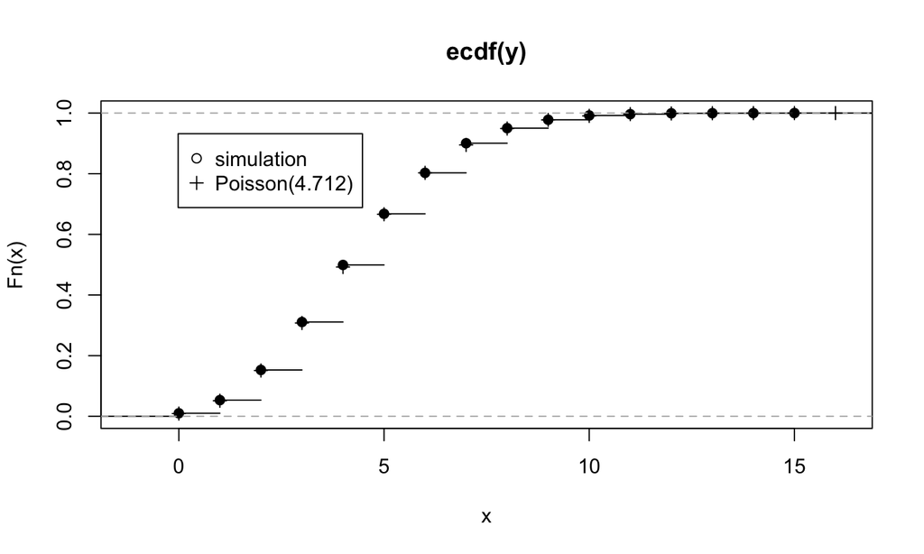

```r
plot(ecdf(y))
points(0:25, ppois(0:25, mu$value), pch = 3)
legend("topleft", inset = 0.1, legend = c("simulation", "Poisson(4.712)"), pch = c(1, 3))
```

## 4.1.2 Renewal Processes (optional)

- Intro.
- Example 4.4

## 4.1.3 Symmetric Random Walk

- Definitions

## Example 4.5 (hint for Ex. 4.1)

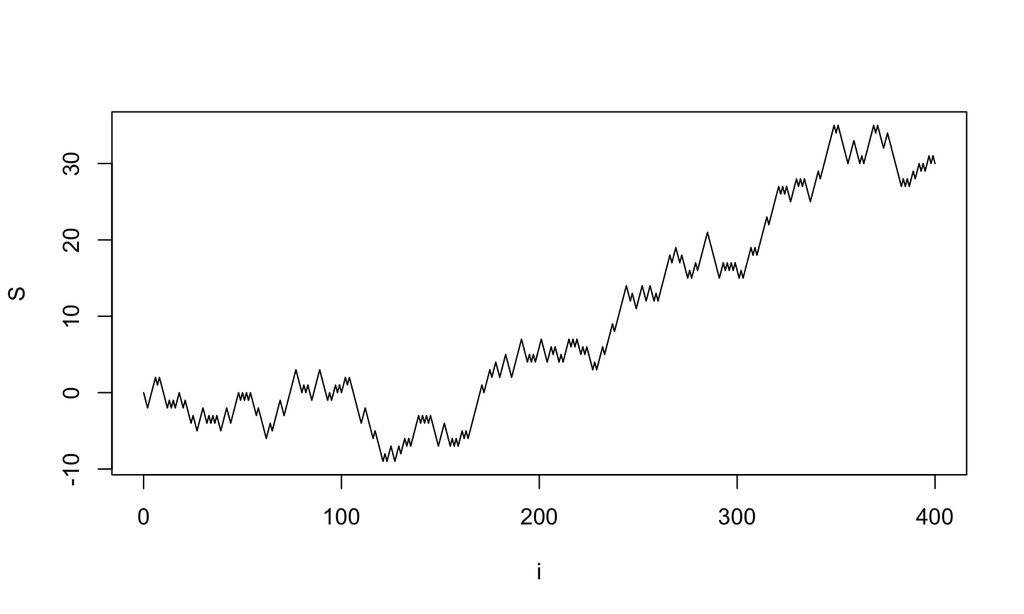

```r
n <- 400
incr <- sample(c(-1, 1), size = n, replace = TRUE)
S <- as.integer(c(0, cumsum(incr)))
plot(0:n, S, type = "l", main = "", xlab = "i")
```

## 4.2 Brownian Motion (optional)

- Definition.
- Example 4.7.

## III. Ch. 4 Problem Set discussion

- Read and discuss 4.1 and 4.3

## Closing

- Students please summarize/ask questions about what we discussed today.
- Other questions?